# Practical Machine Learning Course Project

Kai Xiong

January 25, 2015

## Project Background

Using devices such as Jawbone Up, Nike FuelBand, and Fitbit it is now possible to collect a large amount of data about personal activity relatively inexpensively. These type of devices are part of the quantified self movement – a group of enthusiasts who take measurements about themselves regularly to improve their health, to find patterns in their behavior, or because they are tech geeks. One thing that people regularly do is quantify how much of a particular activity they do, but they rarely quantify how well they do it. In this project, your goal will be to use data from accelerometers on the belt, forearm, arm, and dumbell of 6 participants. They were asked to perform barbell lifts correctly and incorrectly in 5 different ways. More information is available from the website here: http://groupware.les.inf.puc-rio.br/har (see the section on the Weight Lifting Exercise Dataset).

## Data

Six young health participants were asked to perform one set of 10 repetitions of the Unilateral Dumbbell Biceps Curl in five different fashions: exactly according to the specification (Class A), throwing the elbows to the front (Class B), lifting the dumbbell only halfway (Class C), lowering the dumbbell only halfway (Class D) and throwing the hips to the front (Class E).

Class A corresponds to the specified execution of the exercise, while the other 4 classes correspond to common mistakes. Participants were supervised by an experienced weight lifter to make sure the execution complied to the manner they were supposed to simulate. The exercises were performed by six male participants aged between 20-28 years, with little weight lifting experience. We made sure that all participants could easily simulate the mistakes in a safe and controlled manner by using a relatively light dumbbell (1.25kg).

The training data for this project are available here: https://d396qusza40orc.cloudfront.net/predmachlearn/pml-training.csv The test data are available here: https://d396qusza40orc.cloudfront.net/predmachlearn/pml-testing.csv The data for this project come from this source: http://groupware.les.inf.puc-rio.br/har.

## Modeling

### Load and analyse the data

Load caret and ggplot2 library. Download training and testing data to working directory.

```r
library(ggplot2)
library(caret)

training <- read.csv("pml-training.csv", na.string="#DIV/0!", row.names = 1)
testing <- read.csv("pml-testing.csv", na.string="#DIV/0!", row.names = 1)
```

### Clean the data

We remove the columns that have 50% of NA or empty value. We also remove columns with near zero variation as they vary little with the outcomes, which are not necessary.

```
# remove columns that have more than 50% of NA or empty value
threshold <- dim(training)[2]*0.5
columns <- !apply(training, 2, function(x) sum(is.na(x)) > threshold || sum(x == "") > threshold)

# filter the bad training columns
training <- training[, columns]

# columns with zero variation
badColumns <- nearZeroVar(training, saveMetrics = TRUE)

# remove columns with near zero variation
training <- training[, badColumns$nzv == FALSE]

training$classe = factor(training$classe)
```

### Partition data to training set and validation set

```r
inTrain <- createDataPartition(training$classe, p = 0.6)[[1]]
# create cross validation and training data
crossv <- training[ -inTrain, ]
training <- training[ inTrain, ]

inTrain <- createDataPartition(crossv$classe, p = 0.75)[[1]]
crossv_test <-crossv[-inTrain, ]
crossv <- crossv[inTrain, ]
```

Filter near zero columns in the test set

```
testing <- testing[, columns]
testing$classe <- NA
testing <- testing[,badColumns$nzv==FALSE]
```

Feature plot colored by user_name. It would be hard to identify features for each user, especially when the number of users is huge!

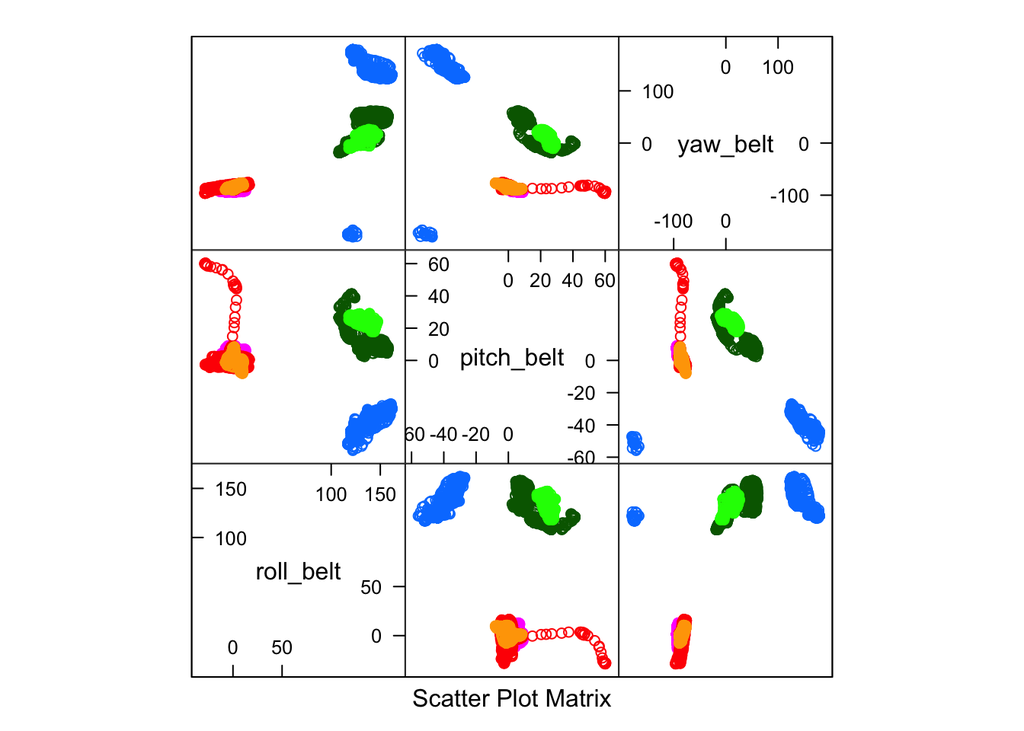

```r
featurePlot(x=training[,c("roll_belt","pitch_belt","yaw_belt")], y=training$user_name, plot="pairs")
```

As there are many features, random forest gives decent performance. I also use principle component analysis to reduce the dimension.

```
model <- train(classe ~ ., data=training, method="rf", preProcess="pca")
# cross validation
pred1 <- predict(mod1, crossv)
```

```r
load("pred1.RData")
confusionMatrix(pred1, crossv$classe)
```

```
## Confusion Matrix and Statistics
##
##           Reference
## Prediction    A    B    C    D    E
##          A 1667   22    4    0    0
##          B    5 1110   20    0    0
##          C    2    7  995   41    0
##          D    0    0    7  923   11
##          E    0    0    0    1 1071
##
## Overall Statistics
##
##                Accuracy : 0.9796
##                  95% CI : (0.9757, 0.9831)
##     No Information Rate : 0.2844
##     P-Value [Acc > NIR] : < 2.2e-16
##
##                   Kappa : 0.9742
##  Mcnemar's Test P-Value : NA
##
## Statistics by Class:
##
##                      Class: A Class: B Class: C Class: D Class: E
## Sensitivity            0.9958   0.9745   0.9698   0.9565   0.9898
## Specificity            0.9938   0.9947   0.9897   0.9963   0.9998
## Pos Pred Value         0.9846   0.9780   0.9522   0.9809   0.9991
## Neg Pred Value         0.9983   0.9939   0.9936   0.9915   0.9977
## Prevalence             0.2844   0.1935   0.1743   0.1639   0.1838
## Detection Rate         0.2832   0.1886   0.1690   0.1568   0.1820
## Detection Prevalence   0.2876   0.1928   0.1775   0.1599   0.1821
## Balanced Accuracy      0.9948   0.9846   0.9797   0.9764   0.9948
```

```
# out of sample error
pred2 <- predict(mod1, crossv_test)
accuracy <- sum(pred2 == crossv_test$classe) / length(pred2)

# predict using test set
pred3 <- predict(mod1, testing)
```

Compute importance of different features.

```
varRF <- varImp(mod1)
```

Plot importance of principle components

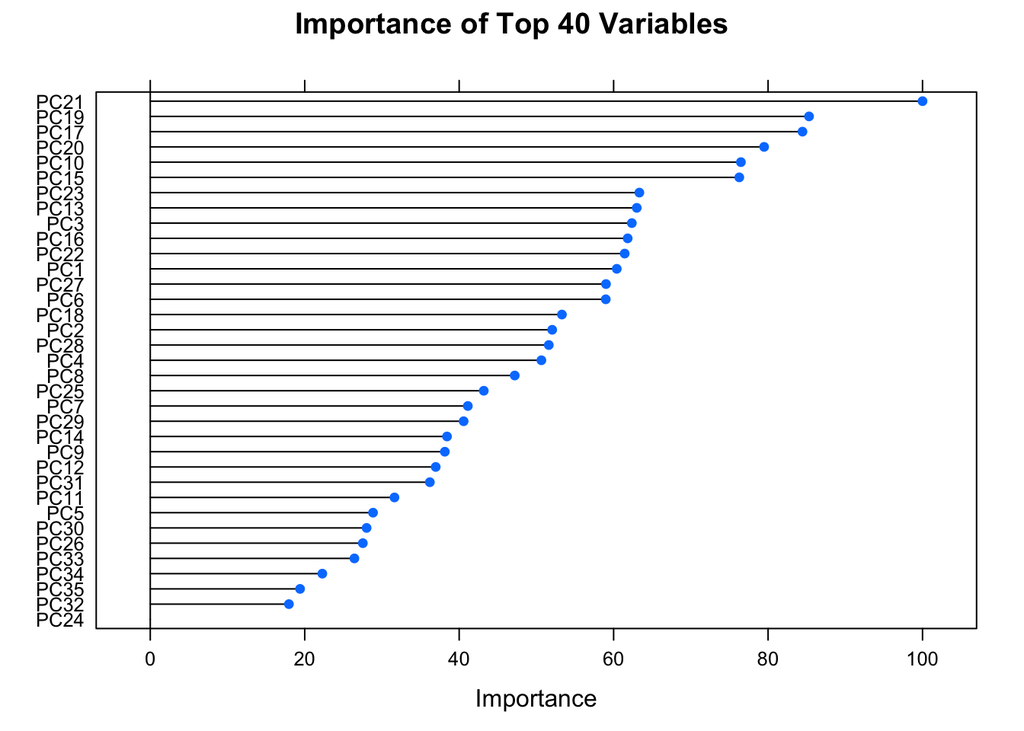

```r
load("varRF.RData")
plot(varRF, main = "Importance of Top 40 Variables")
```

Predict using test set

```r
load("pred3.RData")
pred3
```

```
##  [1] B A B A A E D B A A B C B A E E A B B B
## Levels: A B C D E
```

Write prediction result to files.

```r
pml_write_files = function(x){
  n = length(x)
  for(i in 1:n){
    filename = paste0("problem_id_",i,".txt")
    write.table(x[i],file=filename,quote=FALSE,row.names=FALSE,col.names=FALSE)
  }
}
pml_write_files(pred3)
```